## Infos sur les données de métabolisme

- Nombre de colonne dont la moyenne est nulle : 0
- Nombre de colonne où la variable est constante : 0
- Nombre de NAs dans le dataframe : 0

## Matrices Y et X

| Lignes | Valeur | Colonnes | Valeur |
| --- | --- | --- | --- |
| X | 9 | X | 3 |
| Y | 9 | Y | 724 |

## Test de Blancheur

### Test réalisé :

$H_0 : \{E \text{ suit un bruit blanc et donc } \Sigma = Id \}$

contre

$H_1 : \{E \text{ ne suit pas un bruit blanc et } \Sigma \neq Id \}$

## Structure du bruit des résidus

```
##          Pvalue    Decision
## AR1       0.187 WHITE NOISE
## nonparam      1 WHITE NOISE
## ARMA 2 1  0.179 WHITE NOISE
```

### Test réalisé pour chaque méthode :

$H_0 : \{E\Sigma^{-1/2}_{méthode} \text{ suit un bruit blanc et donc } \Sigma_{corrigé} = Id \}$

contre

$H_1 : \{E\Sigma^{-1/2}_{méthode} \text{ ne suit pas un bruit blanc et } \Sigma_{corrigé} \neq Id \}$

On voit donc que lorsque l’on applique la structure non paramétrique la P-valeur de 1 nous indique que parmi les fonctions testées c’est la structure non paramétrique qui permet de blanchir la matrice.

## Sélection de variables

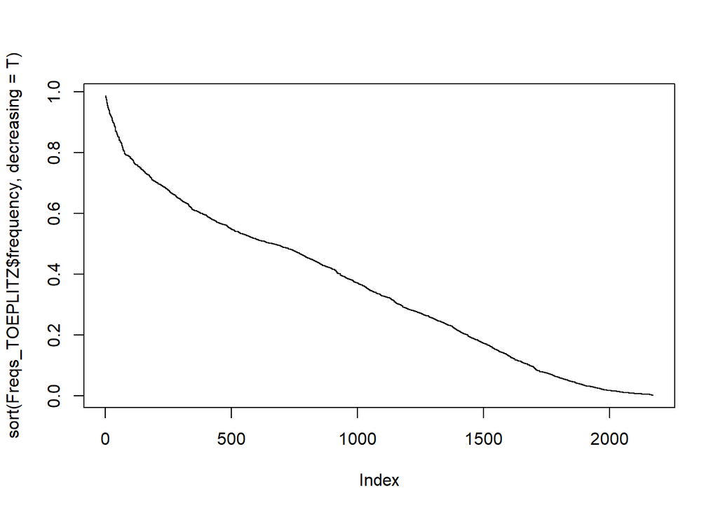

## Les 50 Protéines les plus fréquents

### Liste des fréquences

0.9868, 0.981, 0.976, 0.9734, 0.9712, 0.9636, 0.9612, 0.9544, 0.952, 0.9474, 0.9452, 0.9422, 0.9418, 0.9388, 0.936, 0.9348, 0.9282, 0.926, 0.925, 0.9228, 0.9212, 0.9192, 0.9168, 0.9162, 0.9134, 0.9058, 0.9054, 0.9016, 0.9006, 0.898, 0.8976, 0.8972, 0.8966, 0.895, 0.891, 0.8882, 0.8856, 0.8842, 0.8814, 0.8708, 0.8704, 0.8692, 0.868, 0.865, 0.863, 0.86, 0.8592, 0.8538, 0.8532, 0.8528

### Liste des noms de protéines

AT1G03030.1, AT1G04480.1, AT1G07985.1, AT1G07985.1, AT1G08110.1, AT1G08830.1, AT1G14950.1, AT1G18500.1, AT1G18500.1, AT1G20260.1, AT1G20620.1, AT1G22300.1, AT1G43170.1, AT1G53750.1, AT1G64110.1, AT1G68010.1, AT1G68010.1, AT1G69800.1, AT1G72680.1, AT1G77090.1, AT1G77120.1, AT2G02930.1, AT2G25970.1, AT2G32120.1, AT2G37660.1, AT2G38380.1, AT3G02530.1, AT3G02560.1, AT3G05190.1, AT3G13300.1, AT3G21720.1, AT3G26060.1, AT3G53990.1, AT3G54400.1, AT4G02340.1, AT4G16155.1, AT4G16210.1, AT4G16760.1, AT4G27520.1, AT4G34670.1, AT4G36360.1, AT5G04885.1, AT5G04885.1, AT5G11520.1, AT5G20950.1, AT5G26830.1, AT5G42740.1, AT5G52840.1, AT5G66190.1, AT5G66190.1

## Réponses des Protéines dépassant le seuil 0.95

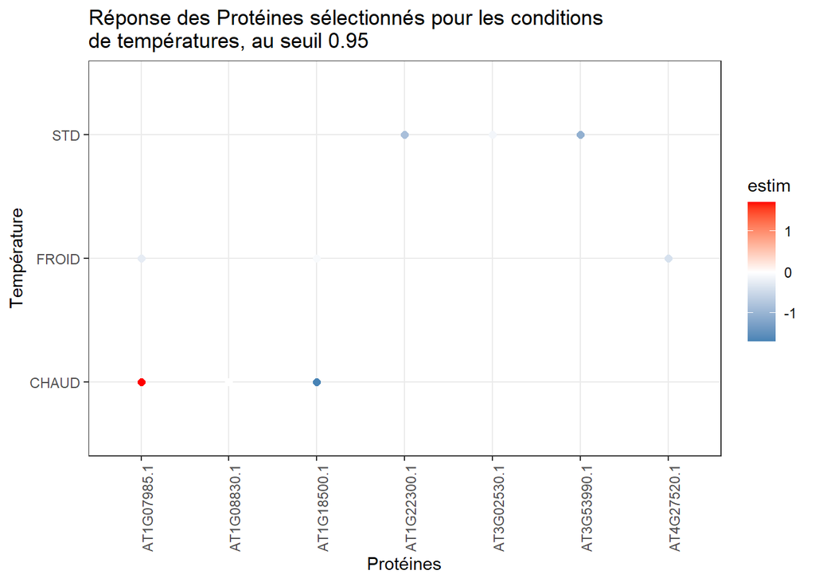

## Boxplots des réponses des Protéines dépassant le seuil 0.95

[figure not shown]

## Protéines retenues au seuil 0.95

### Table des protéines retenues

| Proteines |
| --- |
| AT1G07985.1 |
| AT1G08830.1 |
| AT1G18500.1 |
| AT1G22300.1 |
| AT3G02530.1 |
| AT3G53990.1 |
| AT4G27520.1 |

## Boxplots de Tukey (avec cld)

Les graphiques suivants présentent les boxplots pour les protéines sélectionnées par la méthode du lasso

### AT1G07985.1

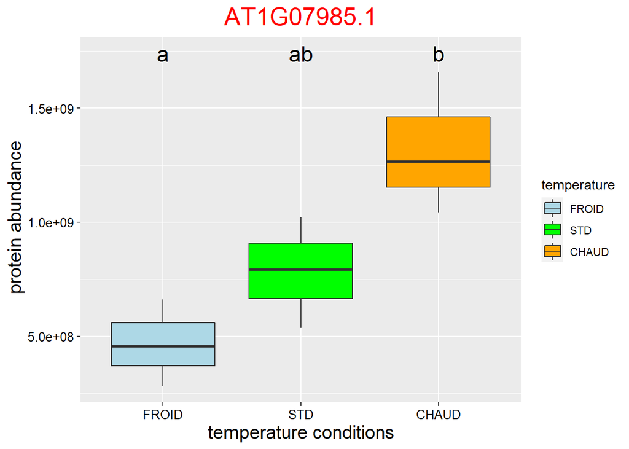

### AT1G08830.1

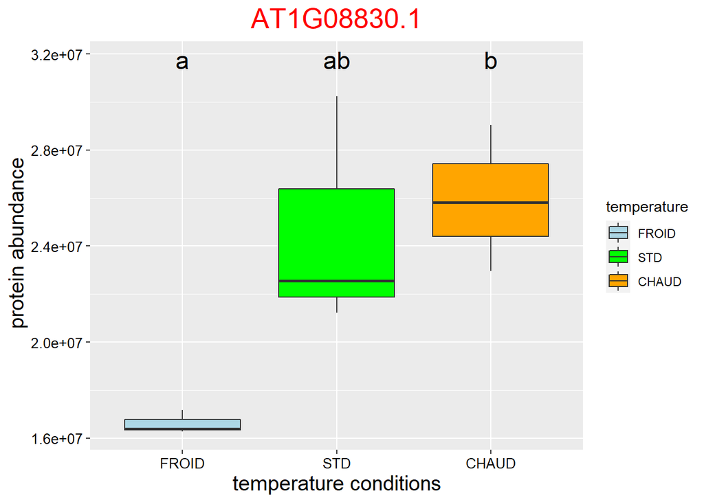

### AT1G18500.1

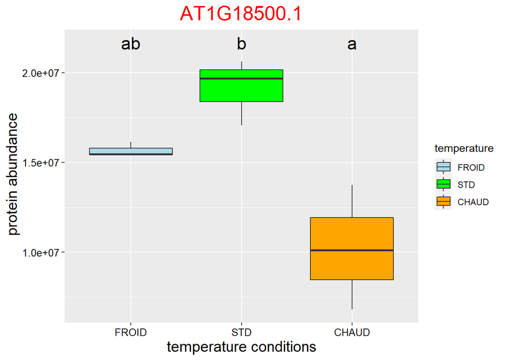

### AT1G22300.1

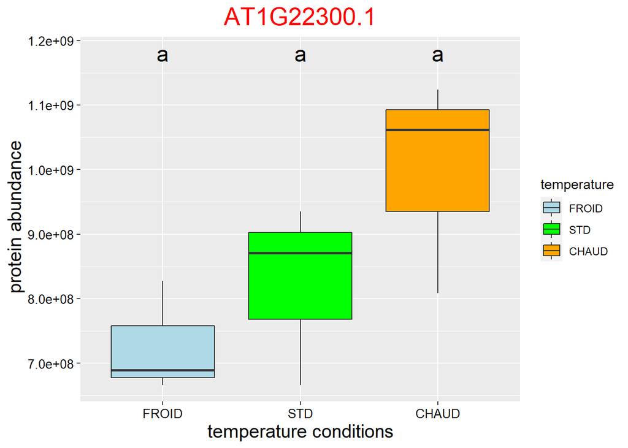

### AT3G02530.1

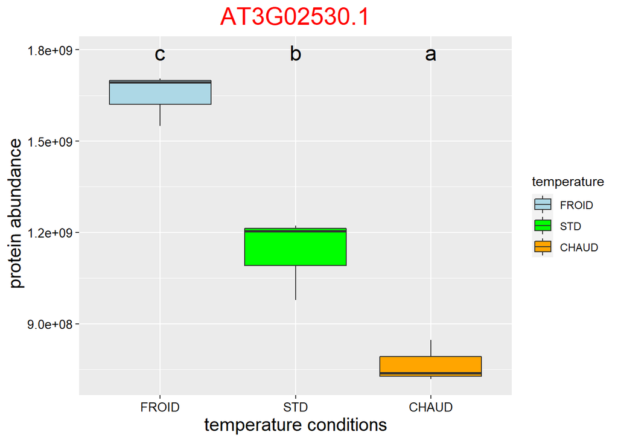

### AT3G53990.1

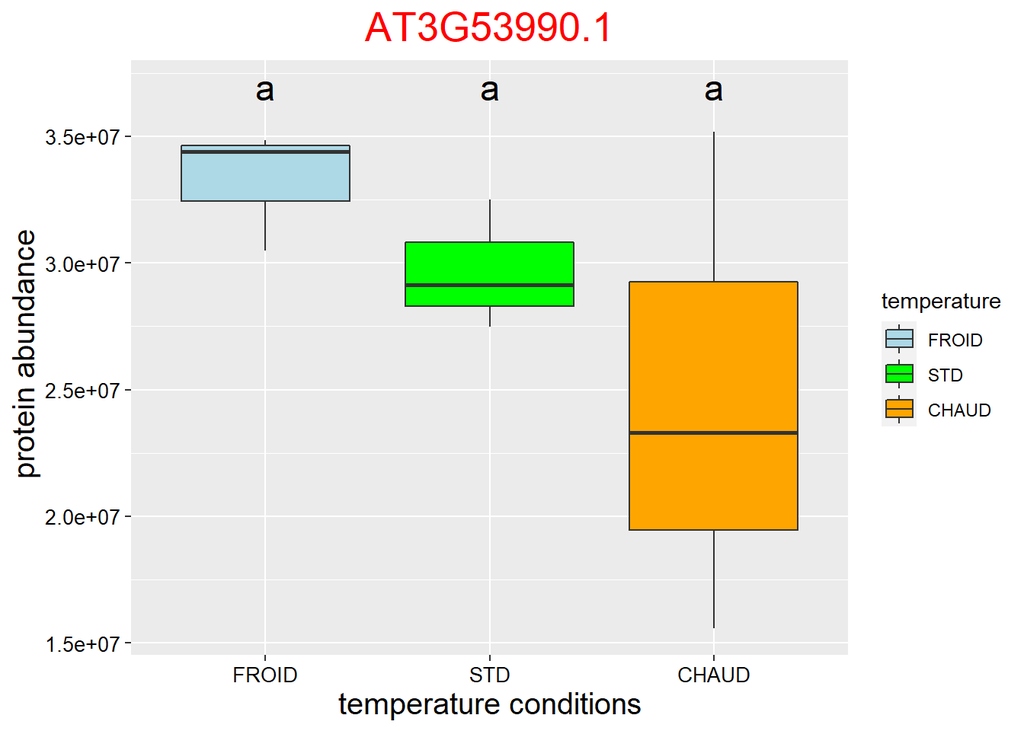

### AT4G27520.1

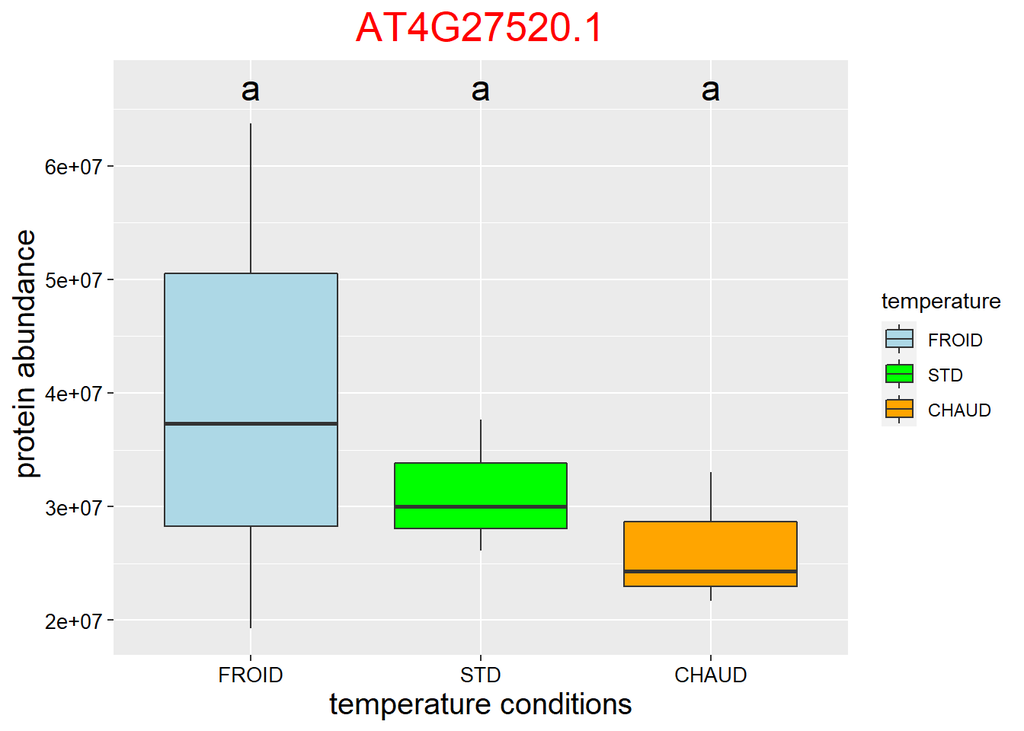

## Exportation des Protéines sélectionnés par GLM Lasso

Le fichier **proteines_selection_lasso_0.95.csv** existe déjà.